# Infancia en riesgo: Un abordaje integral de la mortalidad infantil a nivel global

### Grupo 1% Estadística 99% Fe

**Integrantes**

● María José Marrou Rivera (20171088)

● Daniel Andre Silva Philipps (20207549)

● Edgar Luna Salazar (20197127)

● Jose Navarro Nateros (20202279)

# Objetivo del reporte

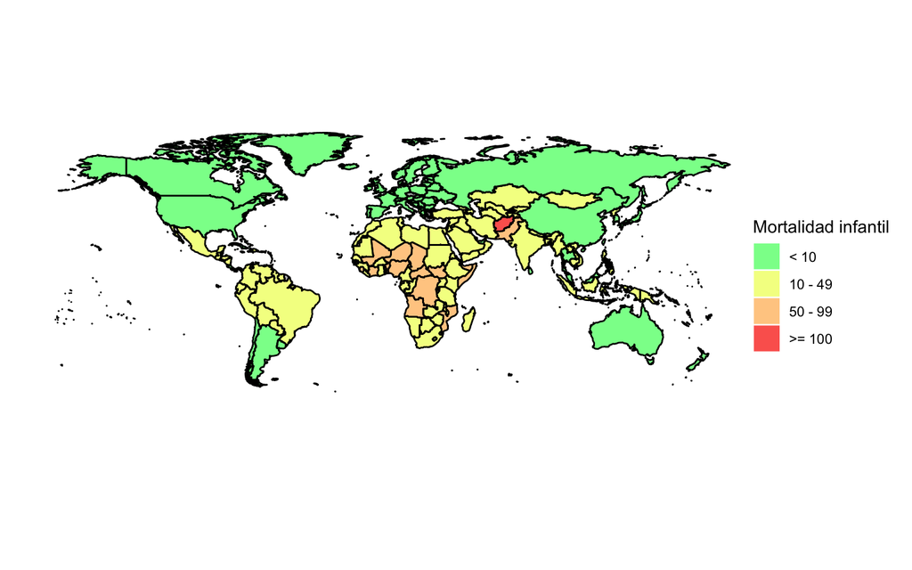

La tasa de mortalidad infantil es un indicador ampliamente utilizado para evaluar el estado de salud de una población y está influenciada por diversos aspectos sociales, culturales y económicos (López et al., 1998). El estudio de la mortalidad infantil proporciona información crucial sobre las principales causas de muerte en niños y su reducción ha sido planteada como un objetivo central en los “Millennium Development Goals” establecidos por las Naciones Unidas en el año 2000, con una fecha límite de 2015 (United Nations, s/f). omo tal, y frente a esos objetivos, es seguro afirmar que un niño tiene más chances de sobrevivir hasta las 5 años hoy de las que tenía en 1990 (UN IGME, 2021) Aunque se ha logrado avances significativos, existen aún brechas importantes entre países desarrollados y aquellos en desarrollo, lo que resalta la necesidad de seguir trabajando para cerrar estas disparidades.

En este contexto, el objetivo de este trabajo es identificar los factores que tienen mayor incidencia en la tasa de mortalidad infantil a nivel mundial, con el fin de brindar información valiosa a los responsables de formular políticas y diseñar intervenciones adecuadas. Para ello, se utiliza un modelo de regresión gaussiana que analiza el impacto de variables explicativas en la mortalidad infantil. Las variables consideradas en el modelo son la expectativa de vida, la desnutrición infantil, la atención prenatal y el índice de saneamiento, las cuales han sido seleccionadas debido a su alta correlación con la variable dependiente mortalidad infantil. Este análisis permitirá obtener una visión más clara de los factores que contribuyen a la mortalidad infantil y facilitará la toma de decisiones informadas para abordar este problema global de manera efectiva.Además, en este estudio se emplea un análisis de conglomerados para organizar los casos en subconjuntos o grupos, utilizando la estrategia divisiva. Esta metodología permite identificar patrones de similitud entre los casos y agruparlos en función de su similitud.

Al combinar el modelo de regresión gaussiana con el análisis de conglomerados, se espera obtener una visión más completa y detallada de los factores que influyen en la mortalidad infantil. Esta combinación de enfoques nos permitirá no solo identificar las variables que tienen mayor incidencia en la tasa de mortalidad infantil, sino también comprender cómo interactúan entre sí y cómo se relacionan en diferentes grupos de casos. De esta manera, se proporcionará información valiosa para la formulación de políticas y la implementación de intervenciones efectivas, teniendo en cuenta las particularidades y los patrones específicos de cada grupo identificado.

# Construcción de la base de datos

La base de datos fue construida mediante la combinación manual de datos obtenidos de diversas fuentes. Principalmente, se utilizaron la página web oficial de la CIA en la sección “Guide to Country Comparisons”, la base de datos del Banco Mundial y la base de datos de la Organización Mundial de la Salud. Todos los datos extraídos corresponden a la versión más actualizada disponible en cada una de estas bases de datos.

Además, se asignaron abreviaturas a cada variable independiente y a la variable dependiente. A continuación, se presenta el significado de cada abreviatura, junto con la base de datos utilizada:

| Variable | Descripción |
| --- | --- |
| Mort | Índice de mortalidad infantil |
| Dsnt | Desnutrición |
| Car | Infraestructura de carreteras |
| GastEdu | Gasto en educación |
| Atenpre | Atención médica prenatal |
| Polineq | Políticas de inclusión y equidad social |
| Sobrep | Sobrepeso infantil |
| Ginico | Índice de Gini |
| Tasdesm | Tasa de desempleo |
| Indsan | Índice de saneamiento |
| Men5bp | Niños menores de 5 años con bajo peso |
| Expvidnc | Expectativa de vida al nacer |
| Emco2 | Emisiones de dióxido de carbono |

## Base de datos

|  | Paises | Mort | GastEdu | Car | Dsnt | Men5bp | Expvidnc | Emco2 | atenpre | sobrep | polineq | Ginico | tasdesm | indsan |
| --- | --- | --- | --- | --- | --- | --- | --- | --- | --- | --- | --- | --- | --- | --- |
| 1 | Afghanistan | 103.06 | 2.9 | 34903 | 19.1 | 19.1 | 54.05 | 7893000 | 65 | 4.1 | 2.7 | 29.4 | 13.28 | 50.5 |
| 2 | Albania | 10.54 | 3.1 | 3945 | 1.5 | 1.5 | 79.7 | 3794000 | 88 | 16.4 | 3.5 | 30.8 | 11.82 | 99.3 |
| 3 | Algeria | 19.22 | 7 | 104 |  | 2.7 | 78.27 | 151633000 | 95 | 12.8 |  | 27.6 | 12.7 | 85.97 |
| 4 | American Samoa | 9.87 |  | 241 |  |  | 75.58 | 355000 |  |  |  |  | 29.8 |  |
| 5 | Andorra | 3.39 | 2.9 | 320 |  |  | 83.61 |  |  |  |  |  | 3.7 | 100 |
| 6 | Angola | 57.2 | 2.4 | 26 | 19 | 19 | 62.51 | 19362000 | 82 | 3.4 | 2.7 | 51.3 | 8.53 | 51.66 |
| 7 | Anguilla | 3.02 | 4 | 175 |  |  | 82.41 |  |  |  |  |  | 8 |  |
| 8 | Antigua and Barbuda | 13.95 | 3.8 | 117 |  |  | 78.04 | 729000 | 100 |  |  |  | 11 |  |
| 9 | Argelia |  |  |  | 2.7 |  |  |  |  | 12.8 |  |  |  |  |
| 10 | Argentina | 9.14 | 5 | 28129 | 2 | 1.7 | 78.55 | 193205000 | 95 | 12.4 |  | 42.3 | 10.9 |  |

[output cut: 228 more lines]

Posteriormente, se realizó la selección de variables correspondientes al mejor modelo y se llevó a cabo el manejo de los valores faltantes (NA’s) utilizando RStudio. Este procedimiento permitió eliminar aquellas observaciones que no disponían de datos para alguna de las variables incluidas en el análisis. De esta manera, se garantizó que los datos utilizados fueran completos y adecuados para el análisis.

# Modelo de Regresión

## **Descripción Univariada**

En primer lugar, se lleva a cabo un análisis descriptivo que genera una tabla resumen de los datos. Este análisis descriptivo es fundamental, ya que proporciona información clave sobre las características de los datos, identifica posibles problemas o patrones existentes y facilita la comunicación de los resultados obtenidos. Al examinar de cerca las estadísticas descriptivas, como medidas de tendencia central, dispersión y distribución de los datos, se obtiene una comprensión más completa de la naturaleza de los datos y se pueden tomar decisiones informadas sobre el análisis posterior.

Descriptivos Univariados

| Variable | Stats / Values | Freqs (% of Valid) | Valid |
| --- | --- | --- | --- |
| Mort [numeric] | Mean (sd) : 19.3 (18.4) min < med < max: 1.5 < 12 < 103.1 IQR (CV) : 21.8 (1) | 217 distinct values | 227 (95.4%) |
| GastEdu [numeric] | Mean (sd) : 4.7 (2.1) min < med < max: 0.3 < 4.5 < 13.6 IQR (CV) : 2.5 (0.4) | 73 distinct values | 196 (82.4%) |
| Car [numeric] | Mean (sd) : 180385.7 (732053.8) min < med < max: 8 < 16000 < 6586610 IQR (CV) : 82163 (4.1) | 219 distinct values | 223 (93.7%) |
| Dsnt [numeric] | Mean (sd) : 9.7 (8.9) min < med < max: 0.2 < 6.8 < 39.9 IQR (CV) : 11.8 (0.9) | 103 distinct values | 156 (65.5%) |
| Men5bp [numeric] | Mean (sd) : 10.5 (9.1) min < med < max: 0.4 < 7.7 < 39.9 IQR (CV) : 13.4 (0.9) | 102 distinct values | 130 (54.6%) |
| Expvidnc [numeric] | Mean (sd) : 74.9 (6.8) min < med < max: 54 < 76.1 < 89.6 IQR (CV) : 9.5 (0.1) | 202 distinct values | 227 (95.4%) |
| Emco2 [numeric] | Mean (sd) : 163750114 (837900495) min < med < max: 0 < 8523000 < 10773248000 IQR (CV) : 53293000 (5.1) | 213 distinct values | 217 (91.2%) |
| atenpre [numeric] | Mean (sd) : 92.4 (10.2) min < med < max: 31 < 97 < 100 IQR (CV) : 10 (0.1) | 33 distinct values | 171 (71.8%) |
| sobrep [numeric] | Mean (sd) : 6.9 (5) min < med < max: 0.8 < 5.9 < 29.6 IQR (CV) : 6.8 (0.7) | 94 distinct values | 157 (66.0%) |
| polineq [numeric] | Mean (sd) : 3.3 (0.5) min < med < max: 1.5 < 3.4 < 4.3 IQR (CV) : 0.6 (0.2) | 21 distinct values | 86 (36.1%) |
| Ginico [numeric] | Mean (sd) : 37.1 (8) min < med < max: 0.3 < 36 < 63 IQR (CV) : 9.3 (0.2) | 127 distinct values | 178 (74.8%) |
| tasdesm [numeric] | Mean (sd) : 8.9 (6.9) min < med < max: 0.1 < 6.8 < 36 IQR (CV) : 7.7 (0.8) | 208 distinct values | 226 (95.0%) |
| indsan [numeric] | Mean (sd) : 76.5 (28.4) min < med < max: 8.9 < 90.3 < 100 IQR (CV) : 44.9 (0.4) | 153 distinct values | 175 (73.5%) |

## **Descripción Bivariada**

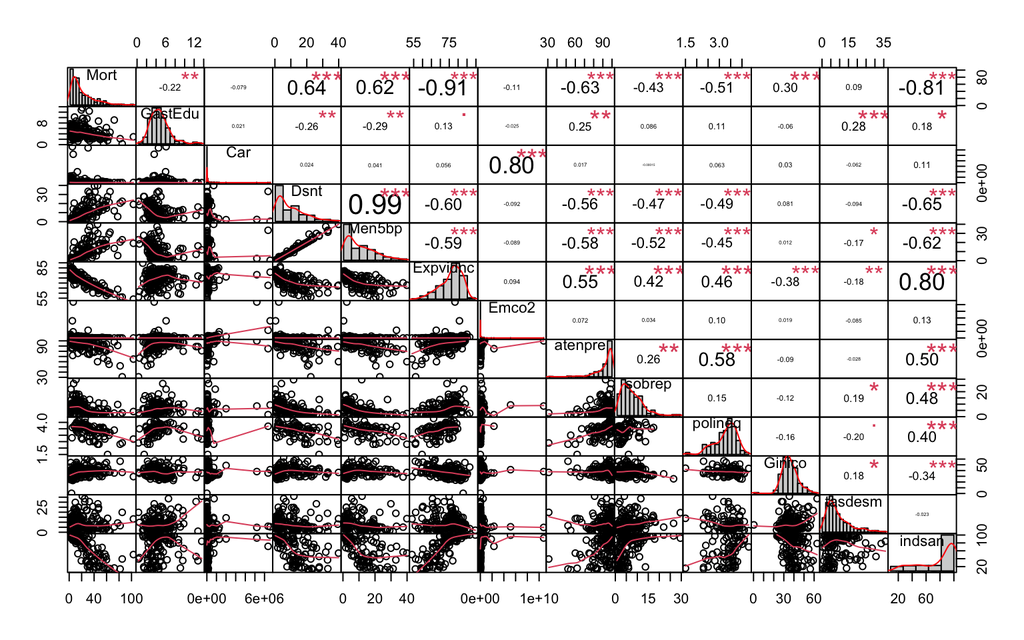

En la elaboración de los modelos de regresión, se consideran únicamente las variables independientes que presentan una correlación absoluta superior a 0.50 con la variable dependiente “Mortalidad infantil” (Mort). Sin embargo, se decide excluir la variable “Niños menores de 5 años con bajo peso” (Men5bp) debido a su alta similitud con la variable “Desnutrición” (Dsnt), lo que podría ocasionar problemas de multicolinealidad.

En el modelo seleccionado se incluyen cuatro variables independientes: “Índice de saneamiento” (Indsan) y “Expectativa de vida al nacer” (Expvidnc), ya que presentan las correlaciones más fuertes con la mortalidad infantil (-0.81 y -0.91, respectivamente), “Desnutrición” (Dsnt) con una correlación de 0.64 y, por último, se incorpora la variable “Atención prenatal” (Atenpre), la cual muestra una correlación de -0.63 con la variable dependiente.

## **Análisis de regresión**

Hipótesis:

> ‘*La mortalidad infantil*’ en el mundo es afectada por *’el índice de saneamiento, la expectativa de vida, la desnutrición infantil y la atención prenatal dentro de un país*’.

```r
modelo3<-lm(Mort~indsan+ Expvidnc+ Dsnt+ atenpre, mor)
summary(modelo3)
```

```
##
## Call:
## lm(formula = Mort ~ indsan + Expvidnc + Dsnt + atenpre, data = mor)
##
## Residuals:
##      Min       1Q   Median       3Q      Max
## -19.4830  -3.3833  -0.5971   3.3112  22.8955
##
## Coefficients:
##               Estimate Std. Error t value Pr(>|t|)
## (Intercept) 231.976385  12.136180  19.114  < 2e-16 ***
## indsan        0.004731   0.039164   0.121  0.90420
## Expvidnc     -2.573088   0.193273 -13.313  < 2e-16 ***
## Dsnt          0.129784   0.110440   1.175  0.24397
## atenpre      -0.237758   0.079108  -3.005  0.00369 **
## ---
## Signif. codes:  0 '***' 0.001 '**' 0.01 '*' 0.05 '.' 0.1 ' ' 1
##
## Residual standard error: 6.845 on 69 degrees of freedom
## Multiple R-squared:  0.8819, Adjusted R-squared:  0.875
## F-statistic: 128.8 on 4 and 69 DF,  p-value: < 2.2e-16
```

Regresion

|  | Mort |
| --- | --- |
| (Intercept) | 231.976*** |
|  | (12.136) |
| indsan | 0.005 |
|  | (0.039) |
| Expvidnc | −2.573*** |
|  | (0.193) |
| Dsnt | 0.130 |
|  | (0.110) |
| atenpre | −0.238** |
|  | (0.079) |
| Num.Obs. | 74 |
| R2 | 0.882 |
| R2 Adj. | 0.875 |
| AIC | 501.5 |
| BIC | 515.3 |
| Log.Lik. | −244.754 |
| F | 128.776 |
| RMSE | 6.61 |

+ p < 0.1, * p < 0.05, ** p < 0.01, *** p < 0.001

Debido a que se obtiene un p-value menor a 0.05, se puede concluir que las variables independientes incluidas en el modelo tienen un impacto conjunto significativo en la variable dependiente. Además, el valor del R ajustado de 0.87 indica que el modelo tiene una buena capacidad para explicar la relación entre la variable dependiente (Mortalidad infantil) y las variables independientes consideradas (índice de saneamiento, expectativa de vida al nacer, desnutrición infantil y atención prenatal).

En general, se puede concluir lo siguiente: (1) Tanto el índice de saneamiento (indsan) como la desnutrición infantil (Dsnt) no presentan una influencia significativa en la mortalidad infantil. (2) No obstante, tanto la expectativa de vida al nacer (Expvidnc) como la atención médica prenatal (atenpre) tienen un efecto estadísticamente significativo, con niveles de significancia de 0.001 y 0.01 respectivamente. (3) Por último, los coeficientes calculados para las variables Expvidnc y atenpre revelan un impacto inverso en la tasa de mortalidad infantil, dado que son negativos. Específicamente, se observa que la expectativa de vida al nacer tiene un efecto con una magnitud de -2.573, mientras que la atención médica prenatal tiene un efecto con una magnitud de -0.237. Estos resultados indican que un incremento de una unidad en ambas variables se asocia a una disminución de 2.573 y 0.237 unidades en la tasa de mortalidad infantil, respectivamente.

Con base en estos resultados, se puede proponer la siguiente ecuación:

$$\begin{equation}
Mort = 231.9763853 + 0.0047312 \cdot indsan + -2.5730878\cdot Expvidnc +
0.1297843\cdot Dsnt + -0.2377579\cdot atenpre + \epsilon
\end{equation}$$

## **Efecto de los regresores**

Regresion: modelo con coeficientes estandarizados

|  | Mort |
| --- | --- |
| (Intercept) | 0.000 |
|  | (0.041) |
| scale(indsan) | 0.007 |
|  | (0.058) |
| scale(Expvidnc) | −0.818*** |
|  | (0.061) |
| scale(Dsnt) | 0.060 |
|  | (0.051) |
| scale(atenpre) | −0.161** |
|  | (0.054) |
| Num.Obs. | 74 |
| R2 | 0.882 |
| R2 Adj. | 0.875 |
| AIC | 62.9 |
| BIC | 76.8 |
| Log.Lik. | −25.467 |
| F | 128.776 |
| RMSE | 0.34 |

+ p < 0.1, * p < 0.05, ** p < 0.01, *** p < 0.001

De los resultados de la tabla, se observa que la variable Expvidnc es la que tiene el efecto más pronunciado en el modelo, seguida por atenpre. Estas dos variables son significativas en el modelo, lo que significa que tienen una relación estadísticamente significativa con la variable dependiente (Mort).

## Diagnóstico de la regresión

| Diagnóstico | Resultado |
| --- | --- |
| Linealidad | -6.72135020313608e-16 |
| Homocedasticidad | 0.0954454136961869 |
| Normalidad de residuos | 0.00541855240387456 |
| No multicolinealidad | 1.95228329881945, 2.20583519257401, 1.53584712164069, 1.68244245458749 |
| Valores influyentes | No hay resultados disponibles |

| Diagnóstico | Resultado |
| --- | --- |
| Linealidad | ✔ |
| Homocedasticidad | ✔ |
| Normalidad de residuos | ❌ |
| No multicolinealidad | ✔ |
| Valores influyentes | ✔ |

En relación al diagnóstico de la regresión, si bien no se cumple la normalidad de residuos, es importante verificar que se cumplan los supuestos de linealidad, homocedasticidad y no multicolinealidad en el modelo de regresión lineal. Estos supuestos permiten asegurar la confiabilidad y precisión de los resultados obtenidos. En el presente estudio, se ha confirmado que se cumplen estos supuestos, además de no encontrar valores influyentes, lo que nos brinda confianza en la idoneidad del modelo para explicar la relación entre las variables predictoras y la variable de respuesta.

# Clusterización

En el contexto de la hipótesis planteada sobre la mortalidad infantil y sus posibles factores influyentes, el análisis de conglomerados permite identificar países que presentan perfiles similares en cuanto a estas variables, lo que podría indicar relaciones o patrones comunes entre ellas y ayudar a comprender mejor los determinantes de la mortalidad infantil. Al agrupar países con características similares, se pueden obtener insights útiles para la formulación de políticas públicas o estrategias de intervención enfocadas en mejorar la salud y bienestar de los niños en diferentes regiones.

Para la realización del analisis de conglomerados, se seleccionan las variables de expectativa de vida (Expvidnc), atención prenatal (atenpre) e índice de saneamiento (indsan) para nuestro análisis de conglomerados. Estas variables forman parte del modelo de correlación anterior. Además, se incluye la variable dependiente Mort y la variable Paises.

Sin embargo, es importante destacar que se decide excluir la variable de desnutrición infantil (Dsnt) debido a las complicaciones que presentaba en el análisis de conglomerados. Esta variable mostraba una correlación negativa con las demás variables, por lo que, aunque se intentó invertir los rangos de la variable, la dirección de la correlación seguía siendo negativa y esto distorsionaba la interpretación de los resultados. De esta manera, se optó por no incluir la variable de desnutrición infantil en el análisis de conglomerados.

## Preparación de los datos para la clusterización

### Exploración de datos

```r
summary(mor1)
```

```
##     Paises               Mort           Expvidnc        atenpre
##  Length:146         Min.   :  1.51   Min.   :54.05   Min.   : 31.00
##  Class :character   1st Qu.: 10.12   1st Qu.:68.04   1st Qu.: 89.00
##  Mode  :character   Median : 19.27   Median :73.98   Median : 96.50
##                     Mean   : 24.44   Mean   :72.63   Mean   : 91.99
##                     3rd Qu.: 32.90   3rd Qu.:77.77   3rd Qu.: 99.00
##                     Max.   :103.06   Max.   :83.99   Max.   :100.00
##      indsan
##  Min.   :  8.91
##  1st Qu.: 48.17
##  Median : 85.88
##  Mean   : 72.36
##  3rd Qu.: 97.89
##  Max.   :100.00
```

### Transformación de datos

[figure not shown]

```r
library(BBmisc)
mor1[,c(3:6)]=normalize(mor1[,c(3:5)],method='standardize')
```

### Correlación

Entre las variables tipificadas, se observan sus correlaciones:

```r
cor(mor1[, c(3:5)])
```

```
##           Expvidnc   atenpre    indsan
## Expvidnc 1.0000000 0.5635453 0.7891069
## atenpre  0.5635453 1.0000000 0.5050705
## indsan   0.7891069 0.5050705 1.0000000
```

En este caso, no existen correlaciones negativas entre las variables, pero de haber incluido la variable de desnutrición, se tendría que invertir los rangos de dicha variable. No obstante, tal y como se mencionó con anterioridad, esta inversión habría dificultado la interpretación de los datos, por lo que se decidió omitir desnutrición en el análisis.

### Matriz de distancia

No se puede usar la columna Pais en la clusterización, pero tampoco debe perderse, por lo que se recomienda usar esos nombres en lugar del nombre de fila.

Una vez están los datos en el objeto dataClus, se calcula la matriz de distancias entre los casos (paises)

```r
library(cluster)
g.dist <- daisy(dataClus, metric = "gower")
```

## Estrategia de jerarquización divisiva

### Gráfico de números óptimos de clusters

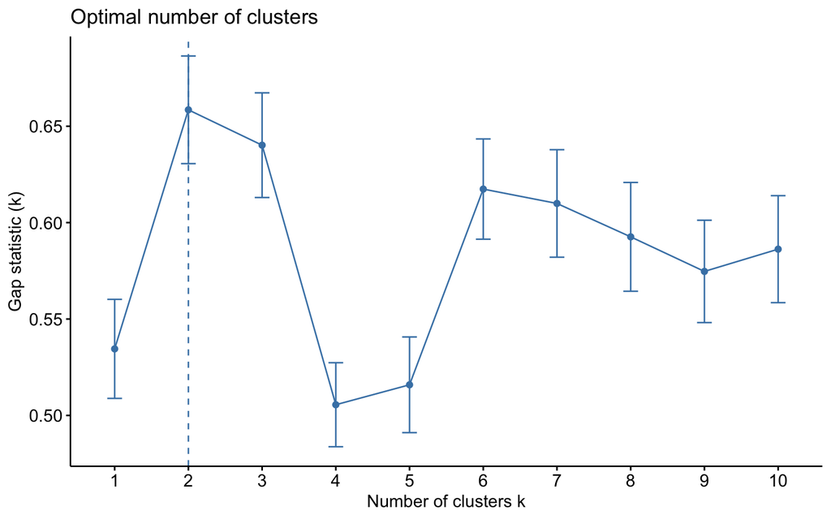

Dado que el resultado del estadístico de gap es 2, se determina la utilización de dos clusters.

### Visualización de los clusters

|  | Expvidnc | atenpre | indsan | diana |
| --- | --- | --- | --- | --- |
| Afghanistan | -2.7565296 | -2.5056172 | -0.7465604 | 1 |
| Albania | 1.0486670 | -0.3701191 | 0.9202087 | 2 |
| Algeria | 0.8365255 | 0.2798151 | 0.4649211 | 2 |
| Angola | -1.5014823 | -0.9272056 | -0.7069405 | 1 |
| Armenia | 0.5591096 | 0.7440538 | 0.7371373 | 2 |
| Australia | 1.5797627 | 0.5583584 | 0.9437757 | 2 |
| Austria | 1.4610821 | 0.7440538 | 0.9430926 | 2 |
| Bahrain | 1.1124578 | 0.7440538 | 0.9441173 | 2 |
| Bangladesh | 0.3454845 | -1.5771398 | -0.6215527 | 1 |
| Barbados | 0.9136678 | 0.0941196 | 0.8788810 | 2 |
| Belarus | 0.2831772 | 0.7440538 | 0.8723915 | 2 |
| Belize | 0.5116373 | 0.4655106 | 0.5414286 | 2 |
| Benin | -1.4881307 | -0.8343578 | -1.8921226 | 1 |
| Bhutan | 0.0562005 | 0.5583584 | 0.1418139 | 2 |
| Bolivia | -0.0194583 | 0.3726629 | -0.2253535 | 2 |

### Dendograma

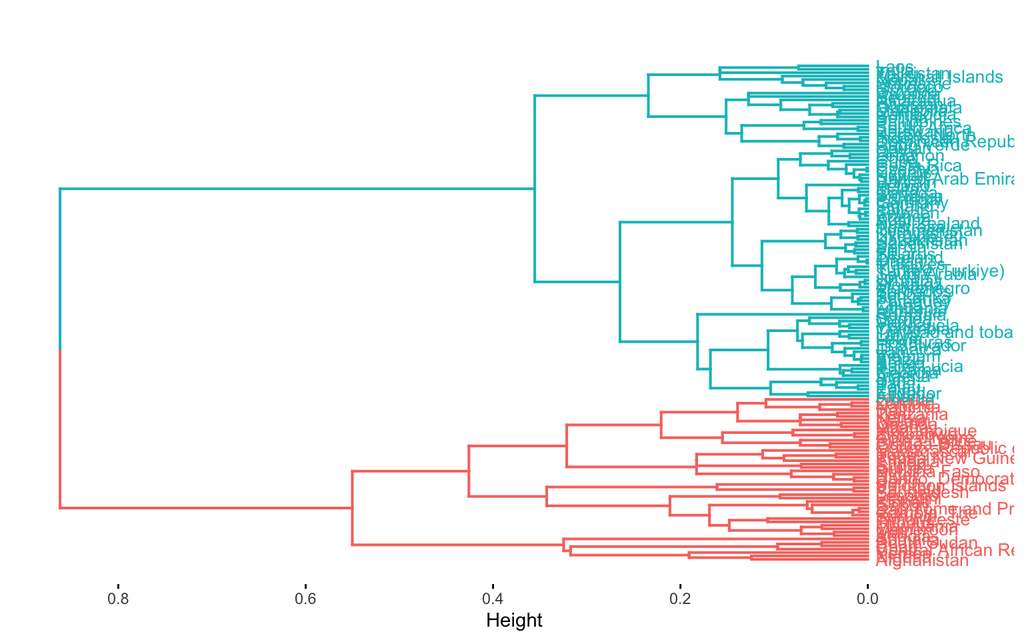

En la estrategia jerárquica divisiva, un valor de “height” de 0.8 implica que los grupos se dividirán en subgrupos más pequeños cuando la distancia entre ellos supere ese umbral.

### Silhouettes para DIANA

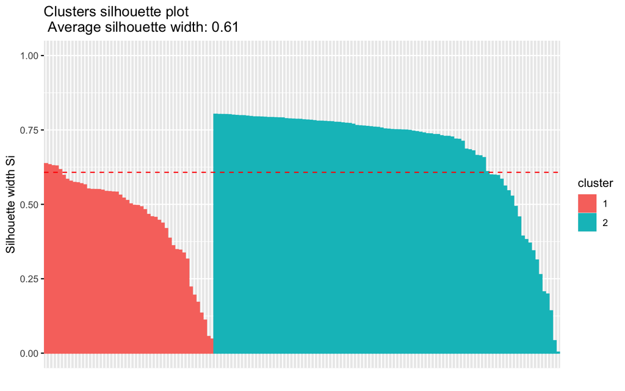

Un ASW de 0.61 indica que los clústeres tienen cierta separación y densidad, pero también puede haber algo de superposición o ambigüedad entre ellos. Esta métrica se utiliza para evaluar la calidad de los clústeres resultantes de un algoritmo de agrupamiento.

Además, se aprecia que no hay países que estén peor clusterizados. Esto se puede corroborar mediante silDIANA.

```r
silDIANA=data.frame(res.diana$silinfo$widths)
silDIANA$country=row.names(silDIANA)
poorDIANA=silDIANA[silDIANA$sil_width<0,'country']%>%sort()
poorDIANA
```

```
## character(0)
```

### Media de los clusters

```r
aggregate(.~ diana, data=dataClus,mean)
```

```
##   diana   Expvidnc    atenpre     indsan
## 1     1 -1.0655474 -0.7163638 -1.2979518
## 2     2  0.5219008  0.3508721  0.6357315
```

Se observa que el grupo 2 se considera mejor en términos de las variables selecciondas. Esto implica que el grupo 2 puede representar países con un mayor expectativa de vida, atención prenatal e índice de saneamiento.

## Gráficos

### Gráfico de DIANA

Se asignan coordenadas a cada país mediante el uso de una matriz de distancia. Una vez aplicado, se obtendrán las coordenadas correspondientes a cada país. Estas coordenadas indicarán la posición de cada país en el plano bidimensional, y se espera que reflejen las distancias entre ellos según lo expresado en la matriz de distancia empleada.

```r
proyeccion = cmdscale(g.dist, k=2,add = T)
head(proyeccion$points,20)
```

```
##                     [,1]         [,2]
## Afghanistan   0.57978531 -0.358512985
## Albania      -0.29820751 -0.168129490
## Algeria      -0.23069989 -0.030330267
## Angola        0.43523234 -0.150343342
## Armenia      -0.28789926  0.022600277
## Australia    -0.39829962  0.058817406
## Austria      -0.40417628  0.066393080
## Bahrain      -0.37990444  0.052930291
## Bangladesh    0.19090693 -0.273734191
## Barbados     -0.30891996 -0.060898400
## Belarus      -0.27323672  0.029046777
## Belize       -0.22307438 -0.006301994
## Benin         0.62561551  0.032836885
## Bhutan       -0.06802905  0.041383602
## Bolivia       0.04363160  0.045763769
## Botswana      0.07408396 -0.009029933
## Brazil       -0.23749284 -0.006046656
## Burkina Faso  0.60675129 -0.006591791
## Burundi       0.28390900  0.191977485
## Cabo Verde   -0.11878313  0.033037877
```

Una vez calculada la proyección, se recuperan las coordenadas del mapa del mundo basado en dimensiones nuevas

Entonces, se visualiza el mapa:

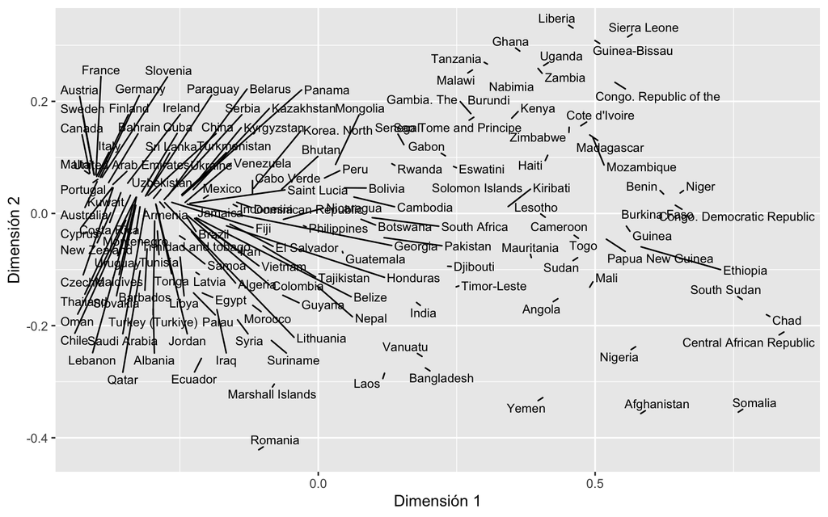

Se colorea el mapa anterior según el cluster al que corresponden.

[figure not shown]

### Gráfica de Barras

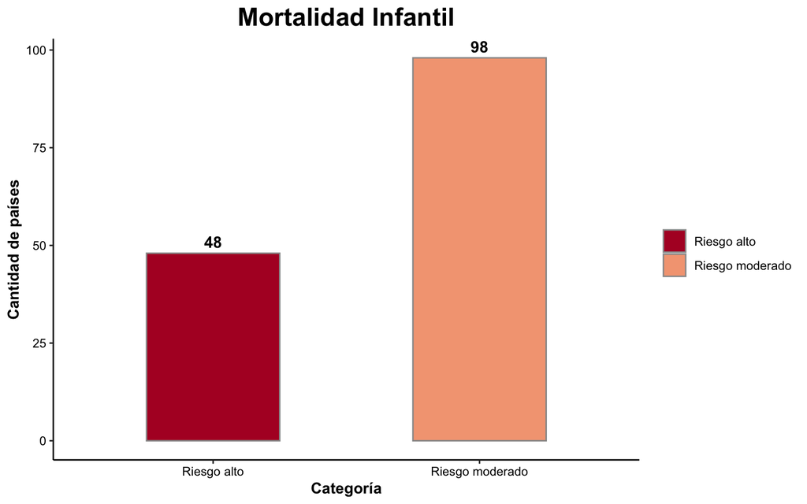

En el siguiente gráfico de barras se muestra que hay una importante diferencia entre el número de países con un riesgo alto de mortalidad infantil (representado en color rojo) y el de países con un riesgo moderado (representado en color naranja).

### Mapa de clusters

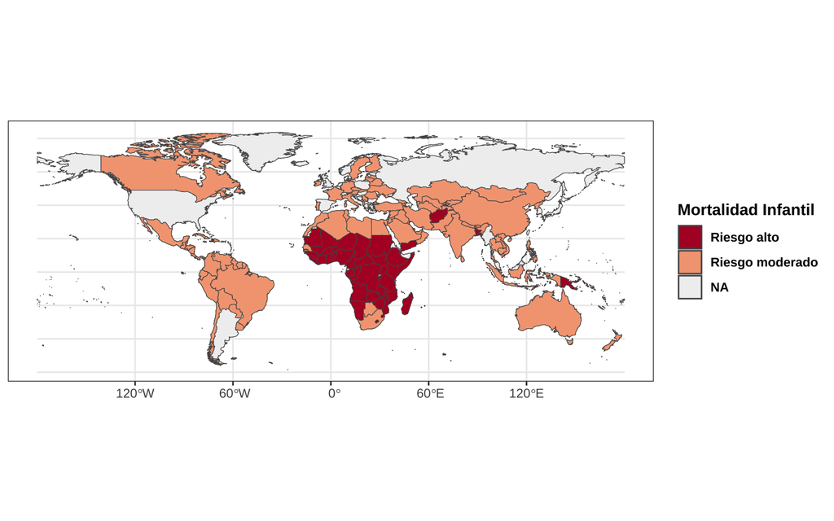

# Conclusión

El último gráfico proporciona una comprensión visual y clara del gráfico DIANA mencionado anteriormente, lo que facilita la interpretación de los resultados y la elaboración de la conclusión. Se pueden identificar dos grupos distintos: uno con riesgo moderado representado en color naranja y otro con riesgo alto representado en color rojo.

En el grupo de riesgo moderado se encuentran países destacados en salud pública que han logrado importantes avances en la prevención de la mortalidad infantil, como los países europeos. Sin embargo, también se incluyen en este grupo algunos países que aún enfrentan desafíos en este aspecto, como los países de América Latina y Oriente Medio.

Por otro lado, el grupo de riesgo alto está compuesto principalmente por países africanos, lo cual confirma la percepción general de que África es el continente más afectado por la mortalidad infantil. Este resultado se respalda en variables como la expectativa de vida, la atención prenatal y el índice de saneamiento, las cuales han demostrado tener un fuerte impacto en la mortalidad infantil según el presente análisis.

No obstante, es importante tener en cuenta que las razones detrás de estas deficiencias en África son aún más diversas, y pueden ir desde la escasez de recursos hasta la falta de interés y corrupción por parte de los líderes políticos. Por lo tanto, un análisis más exhaustivo al respecto será sumamente valioso. Aun así, el aporte del presente análisis es importante porque contribuye a informar a las autoridades y organismos internacionales sobre la situación actual, lo cual incentivará la necesaria implementación de políticas en materia de salud infatil, y servirá como recordatorio del largo camino que aún queda por recorrer para garantizar el desarrollo y el bienestar de las futuras generaciones.

En el caso particular de Perú, si bien se encuentra en el grupo de riesgo moderado, la realidad de su sistema de salud dista mucho de ser satisfactoria. Por lo tanto, es necesario reiterar la importancia de mejorar las políticas de atención prenatal, los sistemas de saneamiento y el acceso a estos servicios en el país, con el objetivo de reducir la mortalidad infantil y garantizar, en general, un mejor servicio de salud para todos los ciudadanos.

En resumen, es fundamental continuar trabajando en la mejora de las condiciones de salud y bienestar de los países, aprovechando los resultados obtenidos a través de este análisis y recordando la importancia de abordar los desafíos específicos de cada región y país. Solo a través de un esfuerzo sostenido y una atención constante a estas problemáticas podremos lograr un futuro mejor para las generaciones venideras.

# Bibliografía

United Nations Inter-Agency Group for Child Mortality Estimation (UN IGME) (2021). Levels and trends in child mortality, consultado el 3 de Julio de 2023. https://data.unicef.org/resources/levels-and-trends-in-child-mortality-2021/

United Nations, United Nations Millennium Development Goals website, consultado el 3 de Julio de 2023. https://www.un.org/millenniumgoals/bkgd.shtml

León López, Rogelio, Gallegos Machado, Bárbara, Estévez Rodríguez, Eduardo, & Rodríguez García, Sonia. (1998). Mortalidad infantil: Análisis de un decenio. Revista Cubana de Medicina General Integral, 14(6), 606-610. https://www.cia.gov/the-world-factbook/references/guide-to-country-comparisons